# Video Game Sales

Taylor de Oliveira Antes - 207114

November 2019

## Introduction

This work will present a data visualization of the dataset vgsales.cls from https://www.kaggle.com/kedokedokedo/vgsales. The packages “knitr” and “ggplot2” are used.

We start by presenting the summary and the structure of the dataset:

```
##       Rank                                Name          Platform
##  Min.   :    1   Need for Speed: Most Wanted:   12   DS     :2163
##  1st Qu.: 4151   FIFA 14                    :    9   PS2    :2161
##  Median : 8300   LEGO Marvel Super Heroes   :    9   PS3    :1329
##  Mean   : 8301   Madden NFL 07              :    9   Wii    :1325
##  3rd Qu.:12450   Ratatouille                :    9   X360   :1265
##  Max.   :16600   Angry Birds Star Wars      :    8   PSP    :1213
##                  (Other)                    :16542   (Other):7142
##       Year               Genre                             Publisher
##  2009   :1431   Action      :3316   Electronic Arts             : 1351
##  2008   :1428   Sports      :2346   Activision                  :  975
##  2010   :1259   Misc        :1739   Namco Bandai Games          :  932
##  2007   :1202   Role-Playing:1488   Ubisoft                     :  921
##  2011   :1139   Shooter     :1310   Konami Digital Entertainment:  832
##  2006   :1008   Adventure   :1286   THQ                         :  715
##  (Other):9131   (Other)     :5113   (Other)                     :10872
##     NA_Sales          EU_Sales          JP_Sales         Other_Sales
##  Min.   : 0.0000   Min.   : 0.0000   Min.   : 0.00000   Min.   : 0.00000
##  1st Qu.: 0.0000   1st Qu.: 0.0000   1st Qu.: 0.00000   1st Qu.: 0.00000
##  Median : 0.0800   Median : 0.0200   Median : 0.00000   Median : 0.01000
##  Mean   : 0.2647   Mean   : 0.1467   Mean   : 0.07778   Mean   : 0.04806
##  3rd Qu.: 0.2400   3rd Qu.: 0.1100   3rd Qu.: 0.04000   3rd Qu.: 0.04000
##  Max.   :41.4900   Max.   :29.0200   Max.   :10.22000   Max.   :10.57000
##
##   Global_Sales
##  Min.   : 0.0100
##  1st Qu.: 0.0600
##  Median : 0.1700
##  Mean   : 0.5374
##  3rd Qu.: 0.4700
##  Max.   :82.7400
##
```

```
## 'data.frame':    16598 obs. of  11 variables:
##  $ Rank        : int  1 2 3 4 5 6 7 8 9 10 ...
##  $ Name        : Factor w/ 11493 levels "¡Shin Chan Flipa en colores!",..: 10991 9343 5531 10993 7364 9707 6648 10989 6651 2594 ...
##  $ Platform    : Factor w/ 31 levels "2600","3DO","3DS",..: 26 12 26 26 6 6 5 26 26 12 ...
##  $ Year        : Factor w/ 40 levels "1980","1981",..: 27 6 29 30 17 10 27 27 30 5 ...
##  $ Genre       : Factor w/ 12 levels "Action","Adventure",..: 11 5 7 11 8 6 5 4 5 9 ...
##  $ Publisher   : Factor w/ 579 levels "10TACLE Studios",..: 369 369 369 369 369 369 369 369 369 369 ...
##  $ NA_Sales    : num  41.5 29.1 15.8 15.8 11.3 ...
##  $ EU_Sales    : num  29.02 3.58 12.88 11.01 8.89 ...
##  $ JP_Sales    : num  3.77 6.81 3.79 3.28 10.22 ...
##  $ Other_Sales : num  8.46 0.77 3.31 2.96 1 0.58 2.9 2.85 2.26 0.47 ...
##  $ Global_Sales: num  82.7 40.2 35.8 33 31.4 ...
```

As shown, the file has 16598 rows/games with 11 columns/variables.

The 11 variables are the following:

```
##  [1] "Rank"         "Name"         "Platform"     "Year"         "Genre"
##  [6] "Publisher"    "NA_Sales"     "EU_Sales"     "JP_Sales"     "Other_Sales"
## [11] "Global_Sales"
```

We will focus our analysis on the following variables:

- Platform
- Year
- Genre
- Global_Sales

## Most and Least Sold Games

The 5 games which were sold the most:

| Name | Platform | Year | Genre | Global_Sales |
| --- | --- | --- | --- | --- |
| Wii Sports | Wii | 2006 | Sports | 82.74 |
| Super Mario Bros. | NES | 1985 | Platform | 40.24 |
| Mario Kart Wii | Wii | 2008 | Racing | 35.82 |
| Wii Sports Resort | Wii | 2009 | Sports | 33.00 |
| Pokemon Red/Pokemon Blue | GB | 1996 | Role-Playing | 31.37 |

And the 5 which were sold the least:

| Name | Platform | Year | Genre | Global_Sales |
| --- | --- | --- | --- | --- |
| Woody Woodpecker in Crazy Castle 5 | GBA | 2002 | Platform | 0.01 |
| Men in Black II: Alien Escape | GC | 2003 | Shooter | 0.01 |
| SCORE International Baja 1000: The Official Game | PS2 | 2008 | Racing | 0.01 |
| Know How 2 | DS | 2010 | Puzzle | 0.01 |
| Spirits & Spells | GBA | 2003 | Platform | 0.01 |

## Platform Analysis

Analysing the Global_Sales vs Platform data:

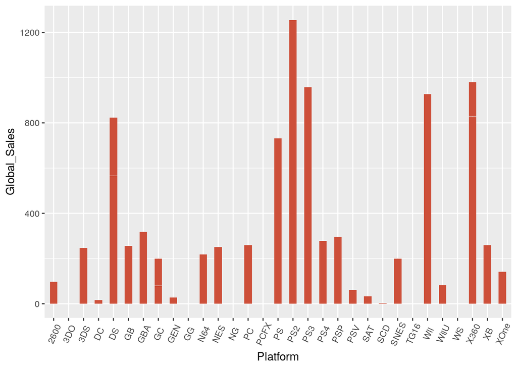

We can see that the platforms with more sales are:

| Platform | Global_Sales | Number_of_Games | Sales_per_Game |
| --- | --- | --- | --- |
| PS2 | 1255.64 | 2161 | 0.5810458 |
| X360 | 979.96 | 1265 | 0.7746719 |
| PS3 | 957.84 | 1329 | 0.7207223 |
| Wii | 926.71 | 1325 | 0.6994038 |
| DS | 822.49 | 2163 | 0.3802543 |

Which is a interesting result, as one would believe that the platform with more sales would be Wii ( because 3 of the top 5 games sold were from the Wii).

## Year Analysis

Analysing the Global_Sales vs Year data:

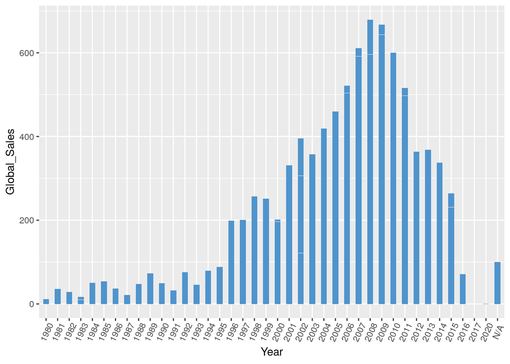

We can see that the years with more sales are:

| Year | Global_Sales | Number_of_Games |
| --- | --- | --- |
| 2008 | 678.90 | 1428 |
| 2009 | 667.30 | 1431 |
| 2007 | 611.13 | 1202 |
| 2010 | 600.45 | 1259 |
| 2006 | 521.04 | 1008 |

This data is related to the platform as well:

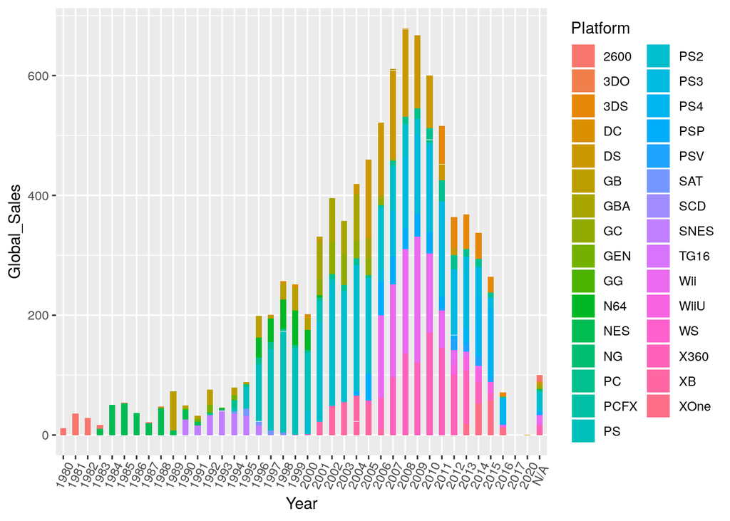

We can see that the increase in the sales from to 2006 to 2010 are distributed pretty even between the platforms with most sales.

## Genre Analysis

Analysing the Global_Sales vs Genre data:

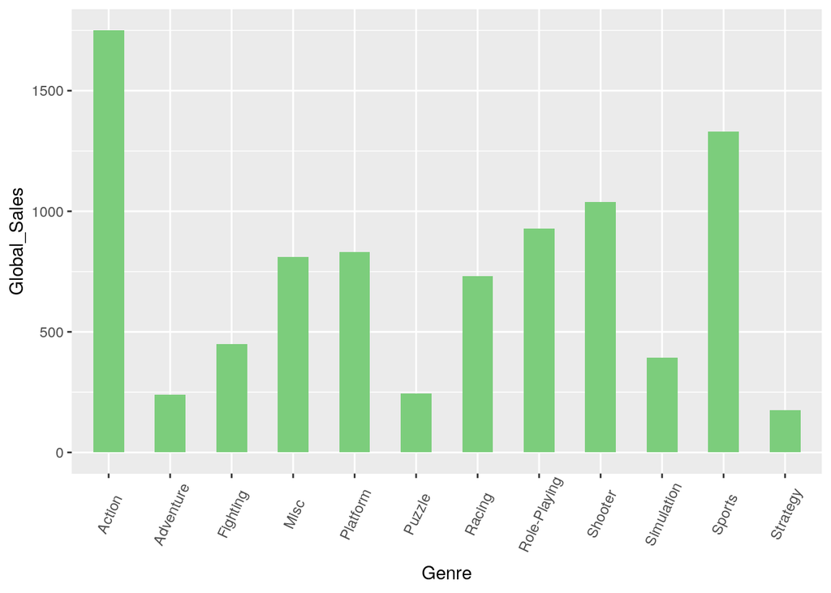

The genres which sold the most were:

| Genre | Global_Sales | Number_of_Games |
| --- | --- | --- |
| Action | 1751.18 | 3316 |
| Sports | 1330.93 | 2346 |
| Shooter | 1037.37 | 1310 |
| Role-Playing | 927.37 | 1488 |
| Platform | 831.37 | 886 |

Analysing the Global_Sales vs Genre per Platform:

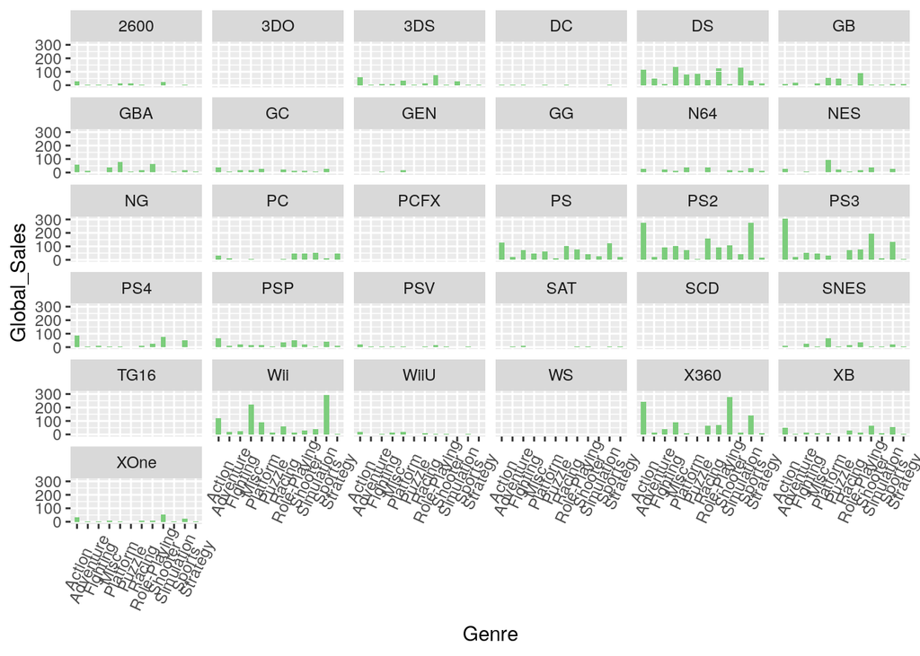